# PART-1:

# Bivariate analysis:

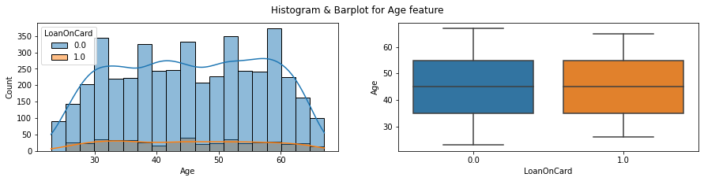

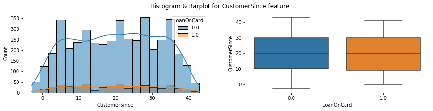

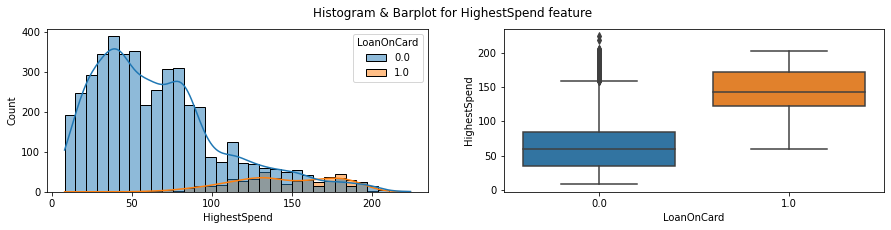

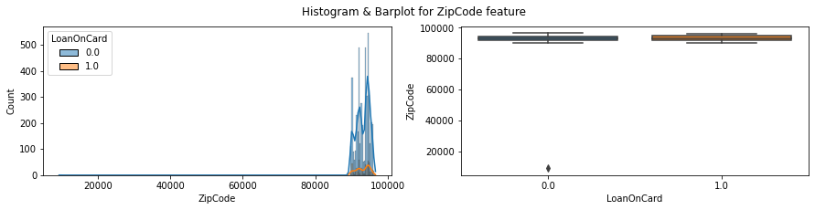

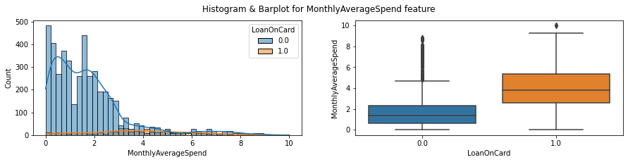

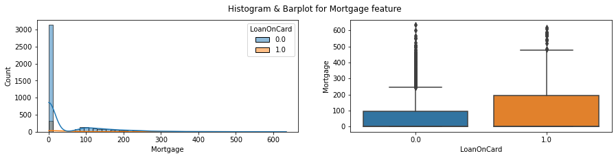

```python
# Lets take LoanOnCard as the Target variable
num_cols = df.select_dtypes(exclude='category').columns.to_list()
for i in num_cols:
    fig,ax=plt.subplots(nrows=1, ncols=2, figsize=(15,3))
    plt.suptitle("Histogram & Barplot for {} feature".format(i), ha='center' )
    sns.histplot(data=df,x=i,ax=ax[0],fill=True, kde=True, hue='LoanOnCard')
    sns.boxplot(x='LoanOnCard',ax=ax[1], y=i, data= df)
```

# Observation:

Age - is assubmed to be evenly splitted across LoanOnCard. There is no much difference other than min and max value.

CustomerSince - same as Age, there is no much difference in old or new customer in terms of LoanOnCard

HighestSpend - customer having LoanOnCard have higher highest spend, where as Lower spend for the customer have no LoanOnCard.

ZipCode - doesn't make much difference.

MonthlyAverageSpend -Customers having LoanOnCard has high MonthlyAverageSpend compared to no loan customers.

Mortgage - Mortgage value is merely starting at 0, however the customer having loan on card has high numbers.

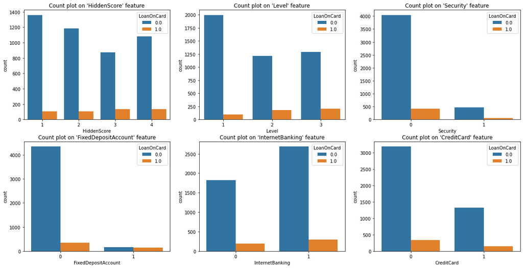

```python
# Target features vs Categorical features
cat=df.select_dtypes(include='category').columns.to_list()
cat.remove('LoanOnCard')
fig, ax= plt.subplots(nrows=2, ncols=3, figsize=(20,10))
ax=ax.flatten()
j=0
for i in cat:
    ax[j].set_title("Count plot on '{}' feature".format(i))
    sns.countplot(data=df, x=i, ax=ax[j], hue='LoanOnCard')
    j=j+1
```

# Observations:

HiddenScore - feature has similar count for all classes for LoanOnCard.

CreditCard - Count of people having credit card is less, in which LoanOnCard distribution is also low.

FixedDepositAccount - People having FixedDeposit, have equal disctibution on LoanOnCard. however, people have no Fixed deposits have less numbers in LoanOnCard.

InternetBanking - Customers having Internet banking have LoanOnCard is slightly higher than no InternetBanking.

CreditCard - Customers having no credit cars also opted for LoanOncard. which is high number compared to customers having credit card. however, proportion may defer.

# Statistical Analysis:

Statistically we can check whether all the independent variables has significant effect on target variable.

```python
# Hypothesis Testing

df.groupby(by=['LoanOnCard']).mean()
```

| LoanOnCard | Age | CustomerSince | HighestSpend | ZipCode | MonthlyAverageSpend | Mortgage |
| --- | --- | --- | --- | --- | --- | --- |
| 0.0 | 45.383111 | 20.146889 | 66.290444 | 93152.337111 | 1.729849 | 51.869111 |
| 1.0 | 45.066667 | 19.843750 | 144.745833 | 93153.202083 | 3.905354 | 100.845833 |

Hypothesis:

Null Hypothesis(Ho):There is no significant difference in independent variables with different category of Target variable

Alternate Hypothesis(H1):There is significant difference in independent variables with different category of Target variable

with 5% Significance level - (0.05)

```python
from scipy.stats import ttest_ind
for i in num_cols:
    sts, p_value = ttest_ind(df[df['LoanOnCard']==0][i],df[df['LoanOnCard']==1][i])
    if p_value<0.05:
        print("P_value: {:.2f} , Reject Null Hypothesis: {} has impact on LoanOnCard".format(p_value,i))
    else:
        print("P_value: {:.2f} , Accept Null Hypothesis: {} has no impact on LoanOnCard".format(p_value,i))
```

```
P_value: 0.57 , Accept Null Hypothesis: Age has no impact on LoanOnCard
P_value: 0.58 , Accept Null Hypothesis: CustomerSince has no impact on LoanOnCard
P_value: 0.00 , Reject Null Hypothesis: HighestSpend has impact on LoanOnCard
P_value: 0.99 , Accept Null Hypothesis: ZipCode has no impact on LoanOnCard
P_value: 0.00 , Reject Null Hypothesis: MonthlyAverageSpend has impact on LoanOnCard
P_value: 0.00 , Reject Null Hypothesis: Mortgage has impact on LoanOnCard
```

Comments:

The features Age, CustomerSince & ZipCode does not have any effect on TargetVariable LoanOnCard. So we can consider removing the feature in modeling.

```python
# Removing the features Age, CustomerSince & ZipCode as it does not affect the Target Variable
df.drop(['Age','CustomerSince','ZipCode'],axis=1,inplace=True)
```

# Chi Square Contingency Test:

Ho: There is no significant difference in hidden score for different category of target variable(LoanOnCard)

H1: There is significant difference in hidden score for different category of target variable(LoanOnCard)

```python
from scipy.stats import chi2_contingency
for i in cat:
    crosstab = pd.crosstab(df['LoanOnCard'],df[i])
    sts, p_value,_,_ = chi2_contingency(crosstab)
    if p_value<0.05:
        print("P_value: {:.2f} , Reject Null Hypothesis: {} has impact on LoanOnCard Class".format(p_value,i))
    else:
        print("P_value: {:.2f} , Accept Null Hypothesis: {} has no impact on LoanOnCard Class".format(p_value,i))
```

```
P_value: 0.00 , Reject Null Hypothesis: HiddenScore has impact on LoanOnCard Class
P_value: 0.00 , Reject Null Hypothesis: Level has impact on LoanOnCard Class
P_value: 0.14 , Accept Null Hypothesis: Security has no impact on LoanOnCard Class
P_value: 0.00 , Reject Null Hypothesis: FixedDepositAccount has impact on LoanOnCard Class
P_value: 0.71 , Accept Null Hypothesis: InternetBanking has no impact on LoanOnCard Class
P_value: 0.90 , Accept Null Hypothesis: CreditCard has no impact on LoanOnCard Class
```

Comments:

Security, InternetBanking, CreditCard has no impact on LoanOncard class. So, we can consider remvoing those feature in model building.

```python
# # Removing the features Security, InternetBanking, CreditCard as it does not affect the Target Variable
df.drop(['CreditCard','InternetBanking','Security'],axis=1,inplace=True)
```

# Multivariate Analysis:

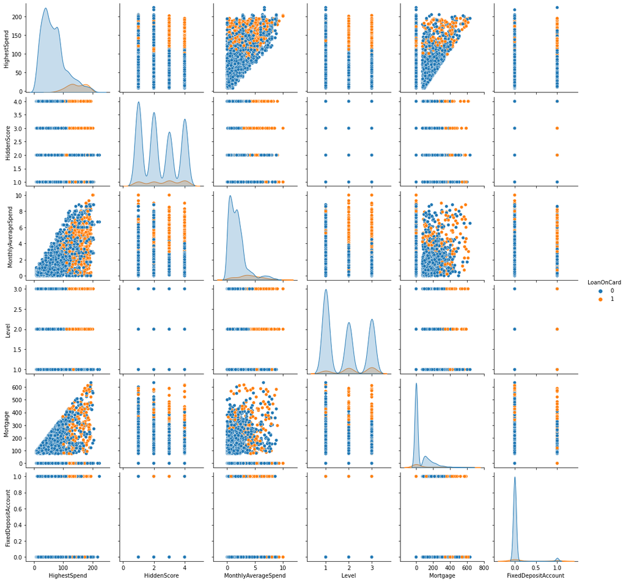

```python
col=['HiddenScore','Level','FixedDepositAccount', 'LoanOnCard']
for i in col:
    df[i]=df[i].astype('int64')
sns.pairplot(df, hue='LoanOnCard')
```

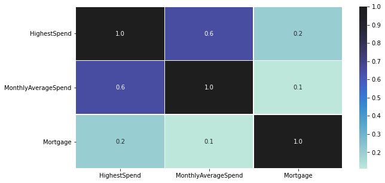

```python
col=['HiddenScore','Level','FixedDepositAccount', 'LoanOnCard']
for i in col:
    df[i]=df[i].astype('category')
plt.figure(figsize=(10,5))
sns.heatmap(df.corr(), annot=True, linewidths=.5, fmt= '.1f', center = 1 )  # heatmap
plt.show()
```

Highest spend has large correlation with monthly average spend

Mortage and highest spend has little correlation

Mortage and monthly average spend has little correlation

```python
df.corr() # It will show correlation matrix
```

|  | HighestSpend | MonthlyAverageSpend | Mortgage |
| --- | --- | --- | --- |
| HighestSpend | 1.000000 | 0.646109 | 0.207236 |
| MonthlyAverageSpend | 0.646109 | 1.000000 | 0.110275 |
| Mortgage | 0.207236 | 0.110275 | 1.000000 |

```python
# However we want to see correlation in graphical representation so below is function for that
def plot_corr(df, size=10):
    corr = df.corr()
    fig, ax = plt.subplots(figsize=(size, size))
    ax.matshow(corr)
    plt.xticks(range(len(corr.columns)), corr.columns)
    plt.yticks(range(len(corr.columns)), corr.columns)
```

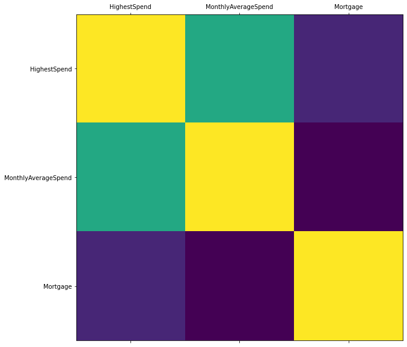

```python
plot_corr(df)
```

In above plot yellow colour represents maximum correlation and blue colour represents minimum correlation.

# 4. Data pre-processing:

• Segregate predictors vs target attributes

• Check for target balancing and fix it if found imbalanced.

• Perform train-test split.

Spliting the data We will use 70% of data for training and 30% for testing.

# Segregate predictors vs target attributes

```python
df['LoanOnCard'].value_counts()
```

```
0    4500
1     480
Name: LoanOnCard, dtype: int64
```

There is imbalance in Target variable with almost 90% data in 0 and 10% data in 1. Let us try to undersample it using sample option in Pandas

```python
sample_data=pd.concat([df[df['LoanOnCard']==0].sample(480),df[df['LoanOnCard']==1]])
X=sample_data.drop('LoanOnCard', axis=1)
y=sample_data['LoanOnCard']
```

```python
X.shape
```

```
(960, 6)
```

```python
y.shape
```

```
(960,)
```

```python
y.value_counts()
```

```
1    480
0    480
Name: LoanOnCard, dtype: int64
```

Imbalance in the dataset has been handled with downsampling the data.

```python
# Perform train-test split.
# Split X and y into training and test set in 70:30 ratio

from sklearn.model_selection import train_test_split
X_train, X_test, y_train, y_test = train_test_split(X, y, test_size=0.30, random_state=10)
```

# 5. Model training, testing and tuning:

# Logistic regression

```
Accuracy score Training dataset:0.90
Accuracy score Testing dataset:0.89
Accuracy score:0.89
Log loss:3.84
              precision    recall  f1-score   support

           0       0.89      0.89      0.89       151
           1       0.88      0.88      0.88       137

    accuracy                           0.89       288
   macro avg       0.89      0.89      0.89       288
weighted avg       0.89      0.89      0.89       288
```

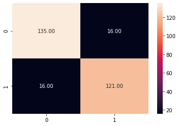

```python
from sklearn.linear_model import LogisticRegression
from sklearn.metrics import accuracy_score, classification_report, confusion_matrix, log_loss
reg = LogisticRegression()

#Try with dataset before downsampling
# df_no_sample = df.drop(['Security','InternetBanking','CreditCard','Age','CustomerSince','ZipCode'], axis=1)
# X1=df_no_sample.drop('LoanOnCard', axis=1)
# y1=df_no_sample['LoanOnCard']

#X_train1, X_test1, y_train1, y_test1 = train_test_split(X1, y1, test_size=0.30, random_state=10)

reg.fit(X_train, y_train)
pred=reg.predict(X_test)

print("Accuracy score Training dataset:{:.2f}".format(reg.score(X_train, y_train)))
print("Accuracy score Testing dataset:{:.2f}".format(reg.score(X_test, y_test)))
print("Accuracy score:{:.2f}".format(accuracy_score(y_test, pred)))
print("Log loss:{:.2f}".format(log_loss(y_test, pred)))
sns.heatmap(confusion_matrix(y_test, pred), annot=True, fmt='.2f')
print(classification_report(y_test,pred))
```

# Observations:

If we see the classification report.

a. Precission : we are predicting 89% of 0 out of over all No Loan on card & 88% of times as Loan on card out of over all dataset.

b. Recall : out of over all dataset, our model can predict 89% of times as No loan on card & 88% of times as Loan on card from test dataset.

For Banks, it is important to hold the potential customers. So our model should predict the less false positive to find our Loan on Card. So we should consider Precission.

```
Accuracy score:88.89 %
Log loss:3.84
              precision    recall  f1-score   support

           0       0.89      0.89      0.89       151
           1       0.88      0.88      0.88       137

    accuracy                           0.89       288
   macro avg       0.89      0.89      0.89       288
weighted avg       0.89      0.89      0.89       288
```

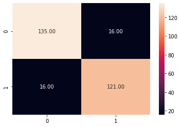

```python
#Try with down sampled data

reg.fit(X_train, y_train)
pred=reg.predict(X_test)

print("Accuracy score:{:.2f} %".format(accuracy_score(y_test, pred)*100))
print("Log loss:{:.2f}".format(log_loss(y_test, pred)))
sns.heatmap(confusion_matrix(y_test, pred), annot=True, fmt='.2f')
print(classification_report(y_test,pred))
```

# Observations:

a. Precission : we are predicting 89% of 0 out of over all No Loan on card & 88% of times as Loan on card out of over all dataset.

b. Recall : out of over all dataset, our model can predict 89% of times correctly as No loan on card & 88% of times as Loan on card correctly.

# Naive Bayes Classification

```
Accuracy score Training dataset:0.82%
Accuracy score Testing dataset:0.82%
Accuracy score: Test vs Predicion: 0.82%
              precision    recall  f1-score   support

           0       0.81      0.86      0.83       151
           1       0.83      0.77      0.80       137

    accuracy                           0.82       288
   macro avg       0.82      0.82      0.82       288
weighted avg       0.82      0.82      0.82       288
```

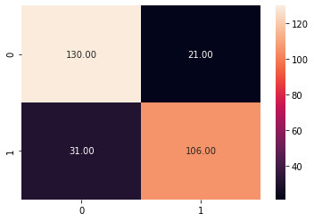

```python
from sklearn.naive_bayes import GaussianNB, BernoulliNB,CategoricalNB,ComplementNB
model = GaussianNB()
model.fit(X_train, y_train)
pred=model.predict(X_test)
print("Accuracy score Training dataset:{:.2f}%".format(model.score(X_train, y_train)))
print("Accuracy score Testing dataset:{:.2f}%".format(model.score(X_test, y_test)))
print("Accuracy score: Test vs Predicion: {:.2f}%".format(accuracy_score(y_test, pred)))

sns.heatmap(confusion_matrix(y_test, pred), annot=True, fmt='.2f')
print(classification_report(y_test,pred))
```

```
Accuracy score Training dataset:61.61%
Accuracy score Testing dataset:57.99%
Accuracy score: test vs Predicion: 57.99%
              precision    recall  f1-score   support

           0       0.59      0.64      0.62       151
           1       0.56      0.51      0.54       137

    accuracy                           0.58       288
   macro avg       0.58      0.58      0.58       288
weighted avg       0.58      0.58      0.58       288
```

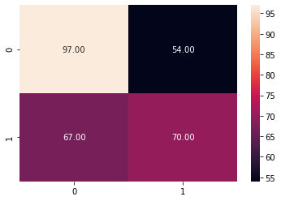

```python
model = BernoulliNB()
model.fit(X_train, y_train)
pred=model.predict(X_test)
print("Accuracy score Training dataset:{:.2f}%".format(model.score(X_train, y_train)*100))
print("Accuracy score Testing dataset:{:.2f}%".format(model.score(X_test, y_test)*100))
print("Accuracy score: test vs Predicion: {:.2f}%".format(accuracy_score(y_test, pred)*100))


sns.heatmap(confusion_matrix(y_test, pred), annot=True, fmt='.2f')
print(classification_report(y_test,pred))
```

```
Accuracy score Training dataset:0.61%
Accuracy score Testing dataset:0.61%
Accuracy score: Test vs Predicion: 0.61%
              precision    recall  f1-score   support

           0       0.61      0.70      0.65       151
           1       0.61      0.52      0.56       137

    accuracy                           0.61       288
   macro avg       0.61      0.61      0.61       288
weighted avg       0.61      0.61      0.61       288
```

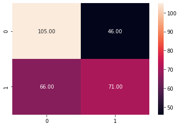

```python
model = ComplementNB()
model.fit(X_train, y_train)
pred=model.predict(X_test)
print("Accuracy score Training dataset:{:.2f}%".format(model.score(X_train, y_train)))
print("Accuracy score Testing dataset:{:.2f}%".format(model.score(X_test, y_test)))
print("Accuracy score: Test vs Predicion: {:.2f}%".format(accuracy_score(y_test, pred)))

sns.heatmap(confusion_matrix(y_test, pred), annot=True, fmt='.2f')
print(classification_report(y_test,pred))
```

# 6. Conclusion and improvisation:

• Write your conclusion on the results. • Detailed suggestions or improvements or on quality, quantity, variety, velocity, veracity etc. on the data points collected by the bank to perform a better data analysis in future.

# Conclusion

I would prefer to choose Logistic regression (balanced data) or GaussianNB as model.

Precision & recall values are better predicting the protential customers.